# GenomicRanges

The GenomicRanges package defines general purpose containers for storing and manipulating genomic intervals and variables defined along a genome. More specialized containers for representing and manipulating short alignments against a reference genome, or a matrix-like summarization of an experiment, are defined in the GenomicAlignments and SummarizedExperiment packages, respectively. Both packages build on top of the GenomicRanges infrastructure.

### install the packges

```r
# if (!requireNamespace("BiocManager", quietly = TRUE))
#     install.packages("BiocManager")
# BiocManager::install("GenomicRanges", version = "3.8")
```

### Storing Generic Ranges with IRanges

IRanges(start=NULL, end=NULL, width=NULL, names=NULL)

```r
#The IRanges package is a dependency of the GenomicRanges package we installed earlier
library(IRanges)
#The ranges we create with the IRanges package are called IRanges objects
rng <- IRanges(start=c(4, 7, 2, 20), end=c(13, 7, 5, 23))
names(rng) <-LETTERS[1:4]
rng
```

```
IRanges object with 4 ranges and 0 metadata columns:
        start       end     width
    <integer> <integer> <integer>
  A         4        13        10
  B         7         7         1
  C         2         5         4
  D        20        23         4
```

```r
library(ggplot2)
a <- plotIRanges(rng) + xlim(0, 30) + ylim(0, 4)
```

```
the existing scale.
```

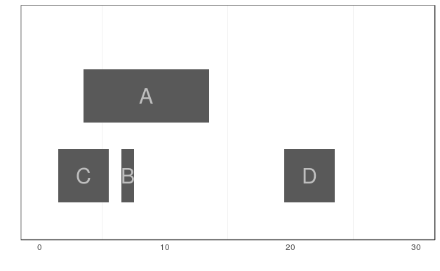

```r
a
```

```r
start(rng)
```

```
[1]  4  7  2 20
```

```r
end(rng)
```

```
[1] 13  7  5 23
```

```r
width(rng)
```

```
[1] 10  1  4  4
```

```r
range(rng)
```

```
IRanges object with 1 range and 0 metadata columns:
          start       end     width
      <integer> <integer> <integer>
  [1]         2        23        22
```

```r
rng[1:3]
```

```
IRanges object with 3 ranges and 0 metadata columns:
        start       end     width
    <integer> <integer> <integer>
  A         4        13        10
  B         7         7         1
  C         2         5         4
```

```r
rng["C"]
```

```
IRanges object with 1 range and 0 metadata columns:
        start       end     width
    <integer> <integer> <integer>
  C         2         5         4
```

```r
rng[start(rng) > 5]
```

```
IRanges object with 2 ranges and 0 metadata columns:
        start       end     width
    <integer> <integer> <integer>
  B         7         7         1
  D        20        23         4
```

```r
m <- IRanges(start = 3, width = 5)
n <- IRanges(start = 6, width = 8)
c(m, n)
```

```
IRanges object with 2 ranges and 0 metadata columns:
          start       end     width
      <integer> <integer> <integer>
  [1]         3         7         5
  [2]         6        13         8
```

```r
end(rng) <- end(rng) + 3
b <- plotIRanges(rng) +  xlim(0, 30)
library("gridExtra")
grid.arrange(a,b)
```

[output not shown]

### Basic Range Operations: Arithmetic, Transformations, ans Set Operations

```r
# With IRanges objects, addition (subtraction) will grow (shrink) a range symmetrically by the value added (subtracted) to it
rng + 4
rng - 4
```

[output not shown]

```r
#restrict() cuts a set of ranges such that they fall inside of a certain bound
y <- IRanges(start = c(4, 6, 10, 12), width = 13)
y
```

```
IRanges object with 4 ranges and 0 metadata columns:
          start       end     width
      <integer> <integer> <integer>
  [1]         4        16        13
  [2]         6        18        13
  [3]        10        22        13
  [4]        12        24        13
```

```r
y.r <- restrict(y, start = 5, end = 10)
y.p <- plotIRanges(y) +  xlim(3, 25)
```

```
the existing scale.
```

```r
y.r.p <- plotIRanges(y.r) +  xlim(3, 25)
```

```
the existing scale.
```

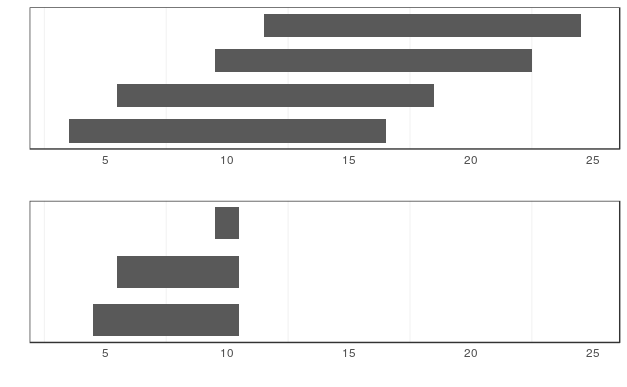

```r
grid.arrange(y.p, y.r.p)
```

```r
# flank() returns the regions that flank (are on the side of) each range in an IRanges object.
# flank() is useful in creating ranges upstream and downstream of protein coding genes that could contain promoter sequences.
# For example, if our ranges demarcate the transition start site (TSS)
# and transcription termination site (TTS) of a set of genes, flank() can be used to create a set of ranges upstream of the TSS that contain promoters.
x <- IRanges(start=c(40, 80), end=c(67, 114))
x
```

```
IRanges object with 2 ranges and 0 metadata columns:
          start       end     width
      <integer> <integer> <integer>
  [1]        40        67        28
  [2]        80       114        35
```

```r
# By default, flank() creates ranges width positions upstream of the ranges passed to it. Flanking ranges downstream can be created by setting start=FALSE:
flank(x, width = 7)
```

```
IRanges object with 2 ranges and 0 metadata columns:
          start       end     width
      <integer> <integer> <integer>
  [1]        33        39         7
  [2]        73        79         7
```

```r
flank(x, width = 7, start = FALSE)
```

```
IRanges object with 2 ranges and 0 metadata columns:
          start       end     width
      <integer> <integer> <integer>
  [1]        68        74         7
  [2]       115       121         7
```

```r
f <- plotIRanges(x) + xlim(20, 125) + ggtitle("original") + theme(plot.title = element_text(hjust = 0.5))
```

```
the existing scale.
```

```r
f.s <- plotIRanges(flank(x, width = 7)) + xlim(20, 125) + ggtitle("upstream") + theme(plot.title = element_text(hjust = 0.5))
```

```
the existing scale.
```

```r
f.e <- plotIRanges(flank(x, width = 7, start = FALSE)) + xlim(20, 125) + ggtitle("downstream") + theme(plot.title = element_text(hjust = 0.5))
```

```
the existing scale.
```

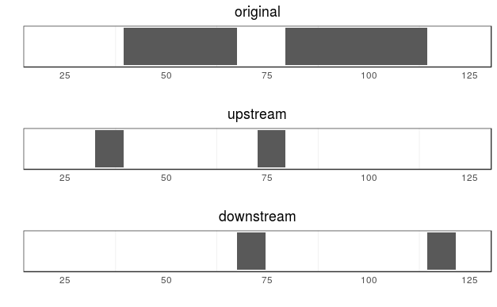

```r
grid.arrange(f, f.s, f.e)
```

```r
# the reduce() operation takes a set of possibly overlapping ranges and reduces them to a set of nonoverlapping ranges that cover the same positions
# gaps() returns the gaps (uncovered portions) between ranges
# gaps() has numerous applications in genomics: creating intron ranges between exons ranges, finding gaps in coverage. defining intragenic regions between genic regions and more
# by default, gaps() only returns the gaps between ranges, and does not include those from the beginning of the sequence to the start position of the first range, and the end of the last range to the end of the sequence.
# If you’d like gaps() to include these gaps, specify the start and end positions in gaps (e.g., gaps(alns, start=1, end=60)).
set.seed(0)
alns <- IRanges(start=sample(seq_len(50), 20), width=5)
head(alns, 5)
```

```
IRanges object with 5 ranges and 0 metadata columns:
          start       end     width
      <integer> <integer> <integer>
  [1]        45        49         5
  [2]        14        18         5
  [3]        18        22         5
  [4]        27        31         5
  [5]        42        46         5
```

```r
reduce(alns)
```

```
IRanges object with 3 ranges and 0 metadata columns:
          start       end     width
      <integer> <integer> <integer>
  [1]         3        22        20
  [2]        24        36        13
  [3]        40        53        14
```

```r
b.r <- plotIRanges(alns) + xlim(0,60) + ylim(0,8) + ggtitle("alns") + theme(plot.title = element_text(hjust = 0.5))
```

```
the existing scale.
```

```r
a.r <- plotIRanges(reduce(alns))+ xlim(0,60) + ylim(0,8) + ggtitle("reduce(alns)") + theme(plot.title = element_text(hjust = 0.5))
```

```
the existing scale.
```

```r
a.g <- plotIRanges(gaps(alns))+ xlim(0,60) + ylim(0,8) + ggtitle("gaps(alns)") + theme(plot.title = element_text(hjust = 0.5))
```

```
the existing scale.
```

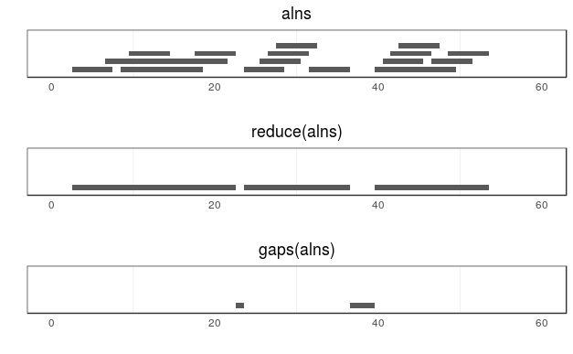

```r
grid.arrange(b.r, a.r, a.g)
```

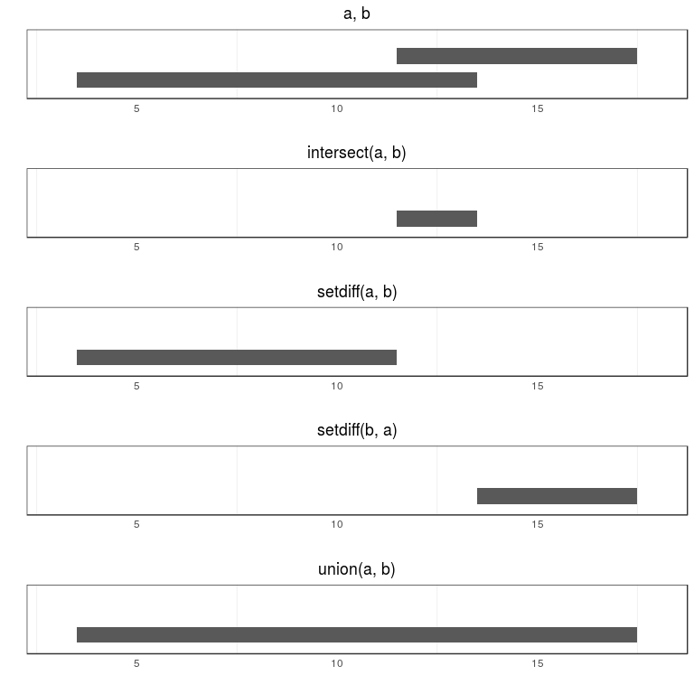

```r
a <- IRanges(start = 4, end = 13)
b <- IRanges(start = 12, end = 17)
a0 <- plotIRanges(c(a, b)) + xlim(3,18) + ylim(0,4) + ggtitle("a, b") + theme(plot.title = element_text(hjust = 0.5))
a1 <- plotIRanges(intersect(a, b)) + xlim(3, 18) + ylim(0,4) + ggtitle("intersect(a, b)") + theme(plot.title = element_text(hjust = 0.5))
a2 <- plotIRanges(setdiff(a, b)) + xlim(3, 18) + ylim(0,4) + ggtitle("setdiff(a, b)") + theme(plot.title = element_text(hjust = 0.5))
a3 <- plotIRanges(setdiff(b, a)) + xlim(3, 18) + ylim(0,4) + ggtitle("setdiff(b, a)") + theme(plot.title = element_text(hjust = 0.5))
a4 <- plotIRanges(union(a, b)) + xlim(3, 18) + ylim(0,4) + ggtitle("union(a, b)") + theme(plot.title = element_text(hjust = 0.5))
grid.arrange(a0, a1,a2,a3,a4, ncol=1 )
```

[figure not shown]

```r
a <- IRanges(start = 1:9, end = 5:13)
b <- IRanges(start = 3:11, end = 9:17)
a0 <- plotIRanges(c(a, b)) + xlim(3,18) + ylim(0,18) + ggtitle("a, b") + theme(plot.title = element_text(hjust = 0.5))
a1 <- plotIRanges(pintersect(a, b)) + xlim(3, 18) + ylim(0,18) + ggtitle("pintersect(a, b)") + theme(plot.title = element_text(hjust = 0.5))
a2 <- plotIRanges(psetdiff(a, b)) + xlim(3, 18) + ylim(0,18) + ggtitle("psetdiff(a, b)") + theme(plot.title = element_text(hjust = 0.5))
a3 <- plotIRanges(psetdiff(b, a)) + xlim(3, 18) + ylim(0,18) + ggtitle("psetdiff(b, a)") + theme(plot.title = element_text(hjust = 0.5))
a4 <- plotIRanges(punion(a, b)) + xlim(3, 18) + ylim(0,18) + ggtitle("punion(a, b)") + theme(plot.title = element_text(hjust = 0.5))
grid.arrange(a0, a1,a2,a3,a4, ncol=1 )
```